# paired_ttest.R

pranav

2020-08-28

```r
# DATA SETS
# Data set 1
```

It represents the sales revenues in 5 different stores, before and after an advertisement campaign.

```r
advertEffect =
  data.frame(
    Store = c(1:5),
    OldSalesRevenue = c(6.4, 5.3, 7.6, 5.5, 7.8),
    NewSalesRevenue = c(7.9, 6.2, 7.1, 6.9, 8.7)
  )
advertEffect
```

```
##   Store OldSalesRevenue NewSalesRevenue
## 1     1             6.4             7.9
## 2     2             5.3             6.2
## 3     3             7.6             7.1
## 4     4             5.5             6.9
## 5     5             7.8             8.7
```

```r
# Data set 2
```

It represents the effect of 3 different drugs on the hours of sleep. Thecontrol group is the group for comparing the effects against.

```r
drugEffect = read.csv("~/Downloads/dataset_for_Q2.csv")
drugEffect
```

```
##    Control drug1 drug2L drug2R delta1 delta2L delta2R
## 1      0.6   1.3    2.5    2.1    0.7     1.9     1.5
## 2      3.0   1.4    3.8    4.4   -1.6     0.8     1.4
## 3      4.7   4.5    5.8    4.7   -0.2     1.1     0.0
## 4      5.5   4.3    5.6    4.8   -1.2     0.1    -0.7
## 5      6.2   6.1    6.1    6.7   -0.1    -0.1     0.5
## 6      3.2   6.6    7.6    8.3    3.4     4.4     5.1
## 7      2.5   6.2    8.0    8.2    3.7     5.5     5.7
## 8      2.8   3.6    4.4    4.3    0.8     1.6     1.5
## 9      1.1   1.1    5.7    5.8    0.0     4.6     4.7
## 10     2.9   4.9    6.3    6.4    2.0     3.4     3.5
```

```r
# QUESTIONS FOR EACH DATA SET
# 1. Use appropriate tests to check equality of means
# 2. Explain clearly why its paired or unpaired
# 3. Do the analysis
```

```r
# TESTS USED
```

```r
# Shapiro-Wilk test:
```

It estimates if a sample’s population is normally distributed

```r
# H_0: Data is normally distributed
# H_1: Data is not normally distributed
# If p-value derived from the test > 0.05, H_0 is accepted.
```

```r
# Paired t-test:
```

It checks if there is a difference between the population means of two dependent samples, together called a paired sample. (A paired sample consists of two samples derived from the same set of entities/events, with the difference being in the conditions of sample collection, called intervention)

```r
# H_0: There is no difference between the sample population means
# H_1: There is difference between the sample population means
# If p-value derived from the test > 0.05, H_0 is accepted.
```

```r
# FOR DATA SET 1
sample1 = advertEffect$OldSalesRevenue
sample2 = advertEffect$NewSalesRevenue
```

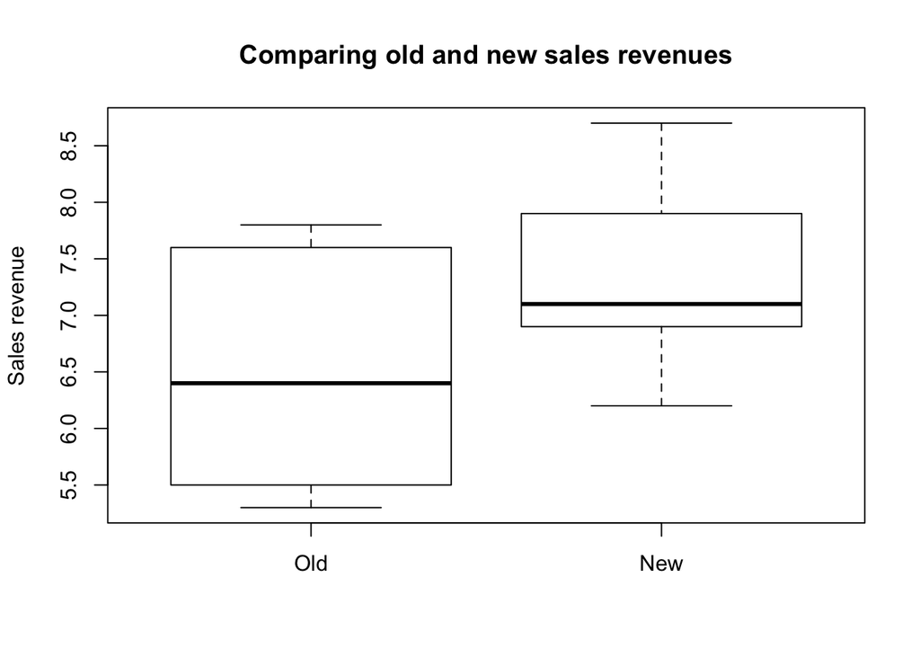

```r
# Box plot of old and new sales revenue
boxplot(
  sample1,
  sample2,
  main = "Comparing old and new sales revenues",
  names = c("Old", "New"),
  ylab = "Sales revenue"
)
```

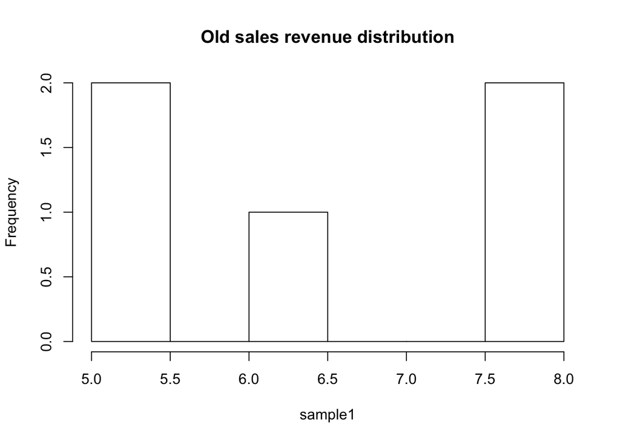

```r
# Histograms of old and new sales revenue
hist(sample1, main = 'Old sales revenue distribution')
```

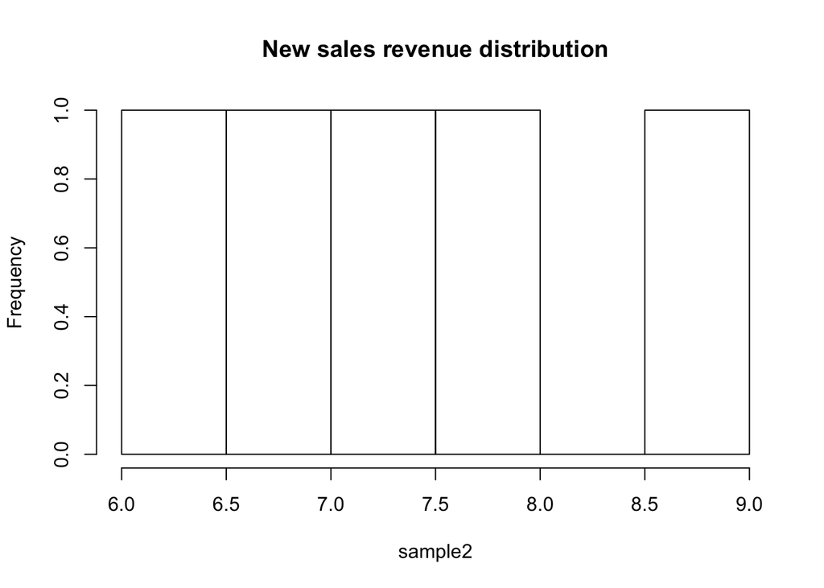

```r
hist(sample2, main = 'New sales revenue distribution')
```

```r
# The samples are paired because
# 1. They are derived from the same entities
#    (the same stores)
# 2. They differ due to a change in condition of sample collection
#    (due to advertisement campaign)
```

```r
# Performing Shapiro-Wilk test to confirm normality
shapiro.test(sample1)
```

```
##
##  Shapiro-Wilk normality test
##
## data:  sample1
## W = 0.87924, p-value = 0.3059
```

```r
shapiro.test(sample2)
```

```
##
##  Shapiro-Wilk normality test
##
## data:  sample2
## W = 0.97555, p-value = 0.9095
```

In both samples, p > 0.05, hence both sample’s populations may be said to follow normal distribution.

```r
# Performing paired t-test
t.test(sample2, sample1, paired = TRUE)
```

```
##
##  Paired t-test
##
## data:  sample2 and sample1
## t = 2.3515, df = 4, p-value = 0.07838
## alternative hypothesis: true difference in means is not equal to 0
## 95 percent confidence interval:
##  -0.1517779  1.8317779
## sample estimates:
## mean of the differences
##                    0.84
```

```r
# p = 0.07838 > 0.05
```

Hence, H_0 is accepted. Hence, we may conclude that the advertisement campaign has no effect on the sales revenue.

```r
# FOR DATA SET 2
```

```r
# T-TEST BETWEEN CONTROL AND DRUG 1
sample1 = drugEffect$Control
sample2 = drugEffect$drug1
```

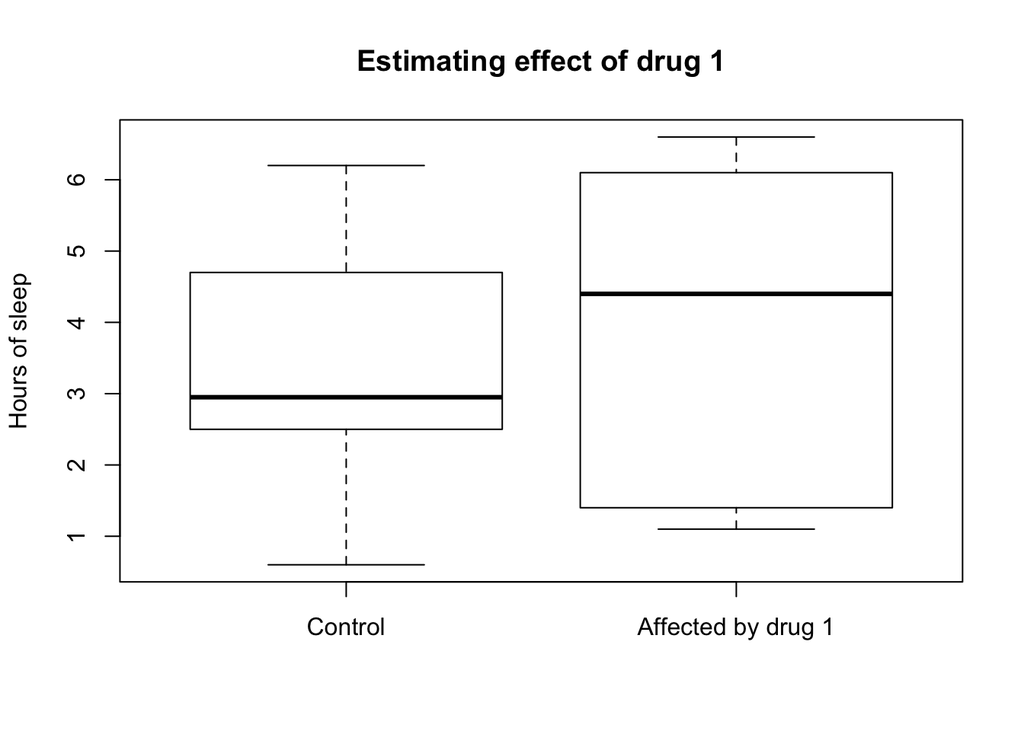

```r
# Box plot of old and new sales revenue
boxplot(
  sample1,
  sample2,
  main = "Estimating effect of drug 1",
  names = c("Control", "Affected by drug 1"),
  ylab = "Hours of sleep"
)
```

```r
# Histograms of control and drug 1 affected hours of sleep
hist(sample1, main = 'Distribution of hours of sleep in control group')
```

[output not shown]

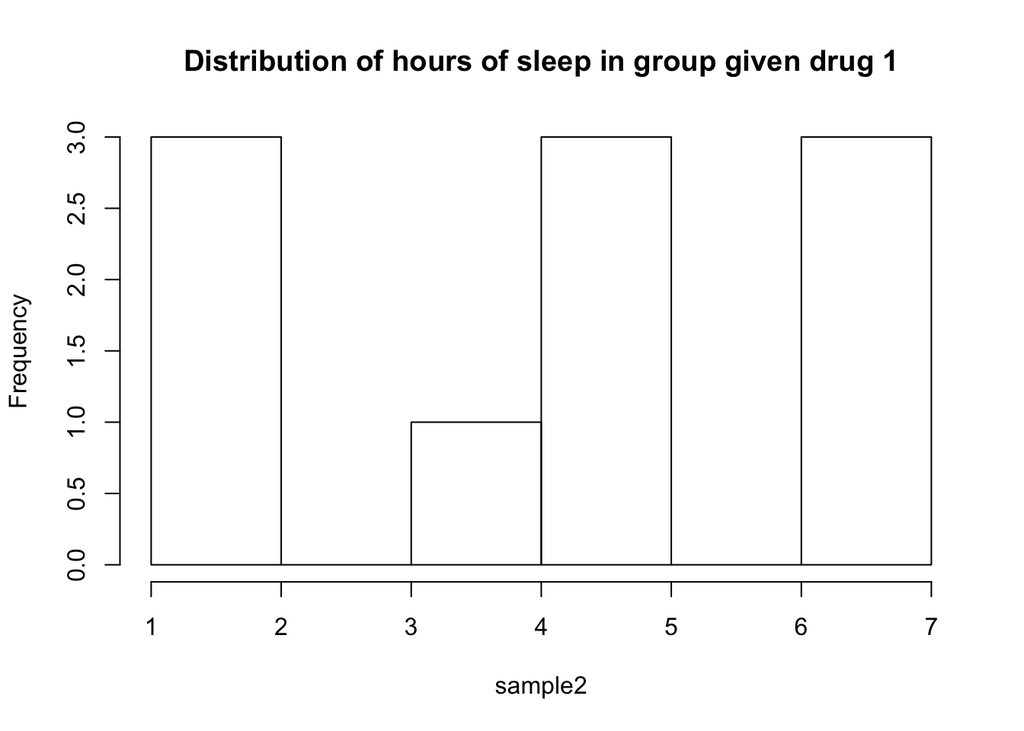

```r
hist(sample2, main = 'Distribution of hours of sleep in group given drug 1')
```

```r
# The samples are paired because
# 1. They are derived from similar entities (people)
#    (the groups are assumed to have the same in physical response to the drugs)
#    (if this were not assumed, the study would not be meaningful)
# 2. They differ due to a change in condition of sample collection
#    (drug effect)
```

```r
# Performing Shapiro-Wilk test to confirm normality
shapiro.test(sample1)
```

```
##
##  Shapiro-Wilk normality test
##
## data:  sample1
## W = 0.94445, p-value = 0.6035
```

```r
shapiro.test(sample2)
```

```
##
##  Shapiro-Wilk normality test
##
## data:  sample2
## W = 0.88771, p-value = 0.1598
```

In both samples, p > 0.05, hence both sample’s populations may be said to follow normal distribution.

```r
# Performing paired t-test
t.test(sample2, sample1, paired = TRUE)
```

```
##
##  Paired t-test
##
## data:  sample2 and sample1
## t = 1.3257, df = 9, p-value = 0.2176
## alternative hypothesis: true difference in means is not equal to 0
## 95 percent confidence interval:
##  -0.5297804  2.0297804
## sample estimates:
## mean of the differences
##                    0.75
```

```r
# p = 0.2176 > 0.05
```

Hence, H_0 is accepted. Hence, we may conclude that the drug 1 has no effect the hours of sleep.

```r
# T-TEST BETWEEN CONTROL AND DRUG 2L
sample2 = drugEffect$drug2L
```

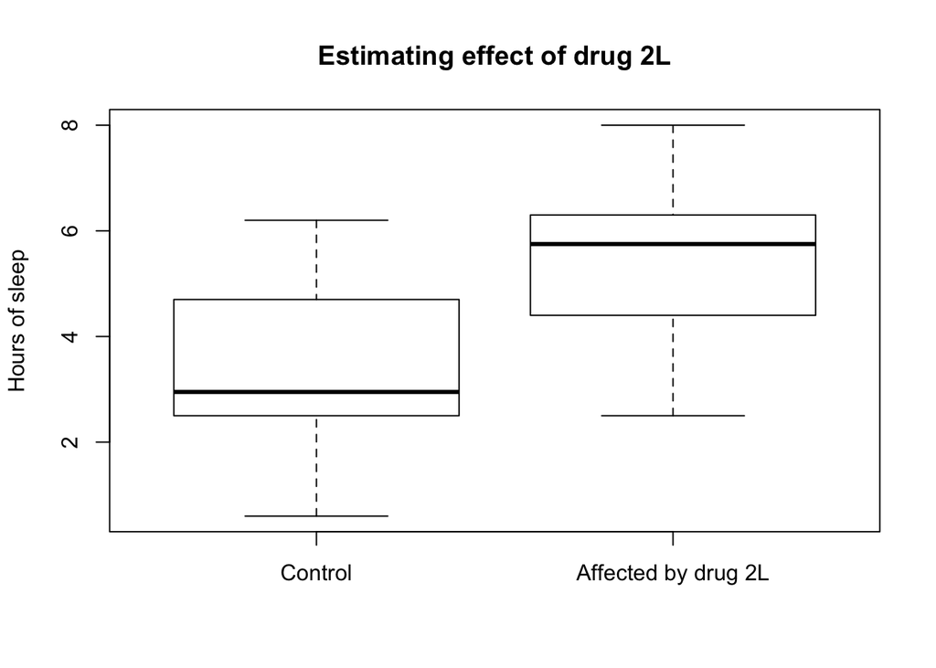

```r
# Box plot of old and new sales revenue
boxplot(
  sample1,
  sample2,
  main = "Estimating effect of drug 2L",
  names = c("Control", "Affected by drug 2L"),
  ylab = "Hours of sleep"
)
```

```r
# Histograms of control and drug 2L affected hours of sleep
hist(sample1, main = 'Distribution of hours of sleep in control group')
```

[output not shown]

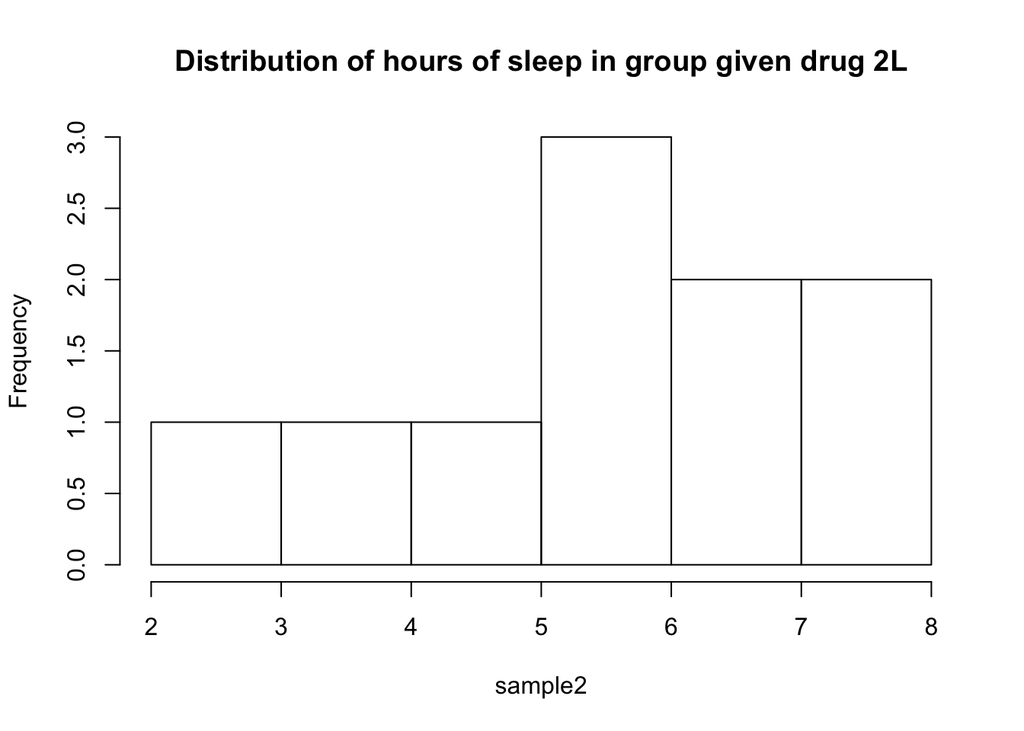

```r
hist(sample2, main = 'Distribution of hours of sleep in group given drug 2L')
```

```r
# The samples are paired because
# 1. They are derived from similar entities (people)
#    (the groups are assumed to have the same in physical response to the drugs)
#    (if this were not assumed, the study would not be meaningful)
# 2. They differ due to a change in condition of sample collection
#    (drug effect)
```

```r
# Performing Shapiro-Wilk test to confirm normality
shapiro.test(sample1)
```

```
##
##  Shapiro-Wilk normality test
##
## data:  sample1
## W = 0.94445, p-value = 0.6035
```

```r
shapiro.test(sample2)
```

```
##
##  Shapiro-Wilk normality test
##
## data:  sample2
## W = 0.95815, p-value = 0.7646
```

In both samples, p > 0.05, hence both sample’s populations may be said to follow normal distribution.

```r
# Performing paired t-test
t.test(sample2, sample1, paired = TRUE)
```

```
##
##  Paired t-test
##
## data:  sample2 and sample1
## t = 3.6799, df = 9, p-value = 0.005076
## alternative hypothesis: true difference in means is not equal to 0
## 95 percent confidence interval:
##  0.8976775 3.7623225
## sample estimates:
## mean of the differences
##                    2.33
```

```r
# p = 0.005076 < 0.05
```

Hence, H_0 is rejected. Hence, we may conclude that the drug 2L has an effect the hours of sleep. Also, mean of differences (i.e. sample2 - sample1) is 2.33. Hence, we can say that drug 2L increases the hours of sleep.

```r
# T-TEST BETWEEN CONTROL AND DRUG 2R
sample2 = drugEffect$drug2R
```

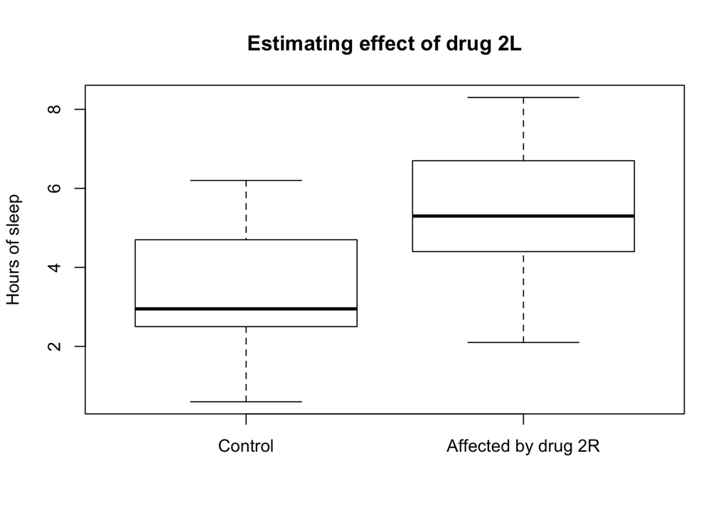

```r
# Box plot of old and new sales revenue
boxplot(
  sample1,
  sample2,
  main = "Estimating effect of drug 2L",
  names = c("Control", "Affected by drug 2R"),
  ylab = "Hours of sleep"
)
```

```r
# Histograms of control and drug 2L affected hours of sleep
hist(sample1, main = 'Distribution of hours of sleep in control group')
```

[output not shown]

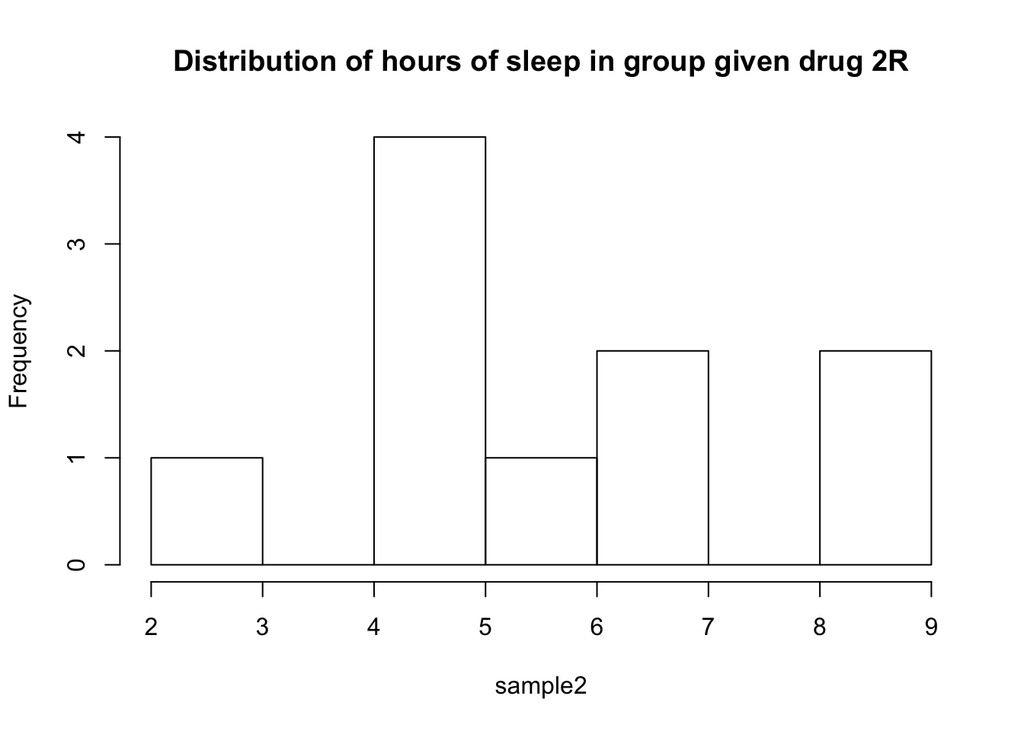

```r
hist(sample2, main = 'Distribution of hours of sleep in group given drug 2R')
```

```r
# The samples are paired because
# 1. They are derived from similar entities (people)
#    (the groups are assumed to have the same in physical response to the drugs)
#    (if this were not assumed, the study would not be meaningful)
# 2. They differ due to a change in condition of sample collection
#    (drug effect)
```

```r
# Performing Shapiro-Wilk test to confirm normality
shapiro.test(sample1)
```

```
##
##  Shapiro-Wilk normality test
##
## data:  sample1
## W = 0.94445, p-value = 0.6035
```

```r
shapiro.test(sample2)
```

```
##
##  Shapiro-Wilk normality test
##
## data:  sample2
## W = 0.95104, p-value = 0.6808
```

In both samples, p > 0.05, hence both sample’s populations may be said to follow normal distribution.

```r
# Performing paired t-test
t.test(sample2, sample1, paired = TRUE)
```

```
##
##  Paired t-test
##
## data:  sample2 and sample1
## t = 3.2375, df = 9, p-value = 0.0102
## alternative hypothesis: true difference in means is not equal to 0
## 95 percent confidence interval:
##  0.6989452 3.9410548
## sample estimates:
## mean of the differences
##                    2.32
```

```r
# p = 0.0102 < 0.05
```

```r
# T-TEST BETWEEN DRIG 2L AND DRUG 2R
sample1 = drugEffect$drug2L
sample2 = drugEffect$drug2R
```

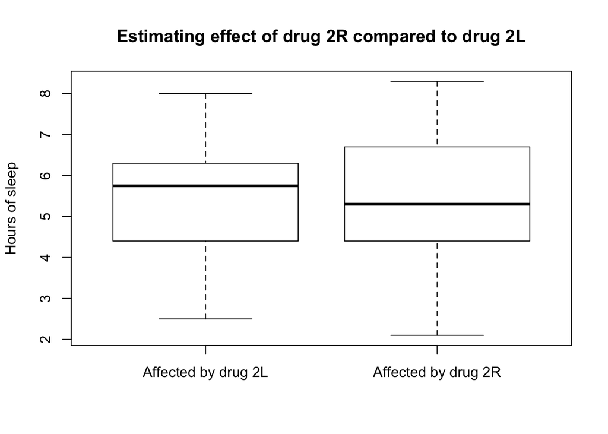

```r
# Box plot of old and new sales revenue
boxplot(
  sample1,
  sample2,
  main = "Estimating effect of drug 2R compared to drug 2L",
  names = c("Affected by drug 2L", "Affected by drug 2R"),
  ylab = "Hours of sleep"
)
```

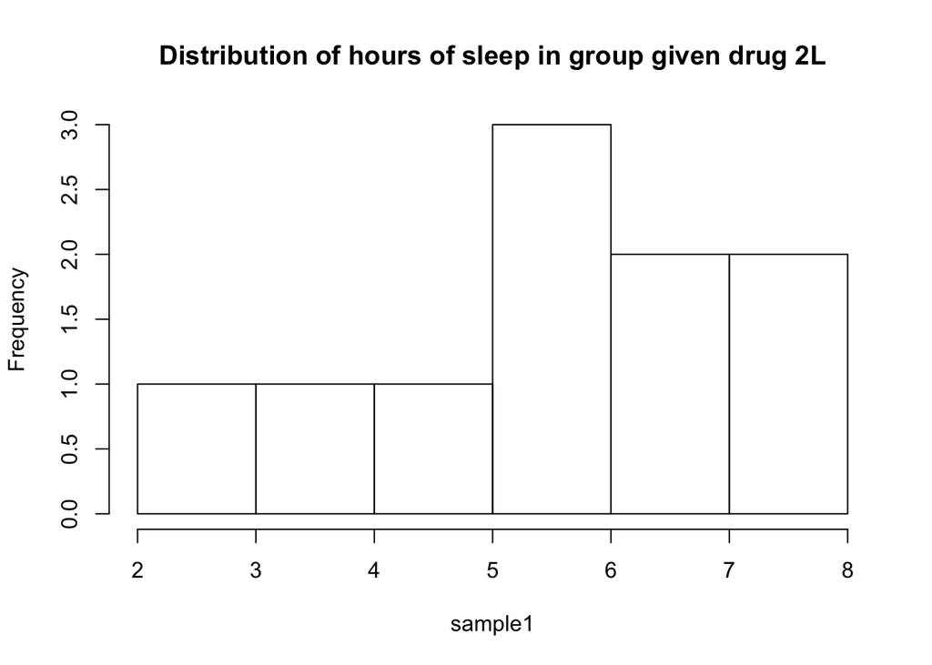

```r
# Histograms of control and drug 2L affected hours of sleep
hist(sample1, main = 'Distribution of hours of sleep in group given drug 2L')
```

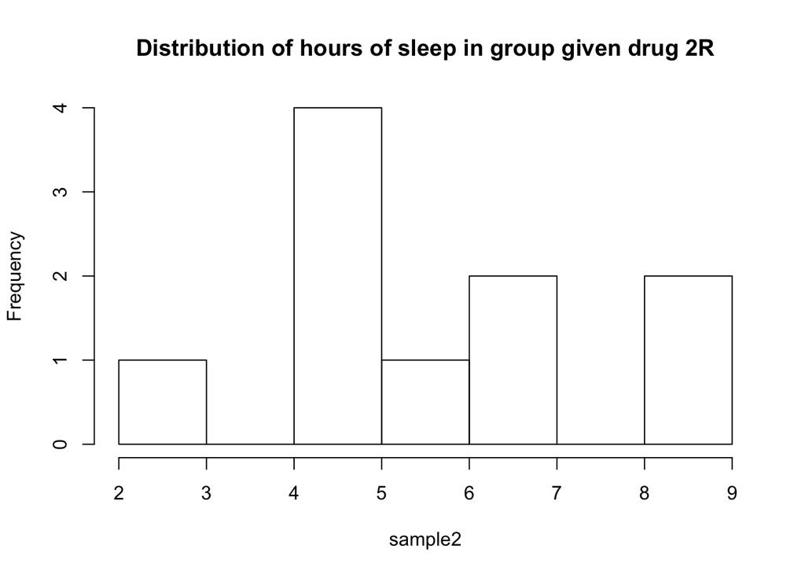

```r
hist(sample2, main = 'Distribution of hours of sleep in group given drug 2R')
```

```r
# The samples are paired because
# 1. They are derived from similar entities (people)
#    (the groups are assumed to have the same in physical response to the drugs)
#    (if this were not assumed, the study would not be meaningful)
# 2. They differ due to a change in condition of sample collection
#    (drug effect)
```

```r
# Performing Shapiro-Wilk test to confirm normality
shapiro.test(sample1)
```

```
##
##  Shapiro-Wilk normality test
##
## data:  sample1
## W = 0.95815, p-value = 0.7646
```

```r
shapiro.test(sample2)
```

```
##
##  Shapiro-Wilk normality test
##
## data:  sample2
## W = 0.95104, p-value = 0.6808
```

In both samples, p > 0.05, hence both sample’s populations may be said to follow normal distribution.

```r
# Performing paired t-test
t.test(sample2, sample1, paired = TRUE)
```

```
##
##  Paired t-test
##
## data:  sample2 and sample1
## t = -0.052311, df = 9, p-value = 0.9594
## alternative hypothesis: true difference in means is not equal to 0
## 95 percent confidence interval:
##  -0.4424476  0.4224476
## sample estimates:
## mean of the differences
##                   -0.01
```

```r
# p = 0.9594 > 0.05
```

```r
# OVERALL CONCLUSION
```

Based on the results, we can say that while drug 1 seems to be inffective in affecting the hours of sleep, drug 2L and drug 2R do affect the hours of sleep identically.